```r
fig_nums(name='hist_cont_filt', caption='Histograma de conteos por histograma (log10)', display=F)
table_nums(name='sample_group', caption = 'Muestras por grupo', display=F)
table_nums(name='sample_sel', caption = 'Muestras seleccionadas', display=F)
out_nums(name='se_output', caption='Summarized Experiment', display=F)
```

# Selección aleatoria de los datos

Seleccionamos diez muestras por grupo.

```r
# Only select and save the samples once, and set the sample seed just in case we have to resamples the same population
set.seed(28052020)
selected_data_file <- 'selected_data.Rdata'

if (!file.exists(selected_data_file)) {
  targets <- read_csv('../data/targets.csv') %>%
    group_by(Group) %>%
    sample_n(10) %>%
    arrange(Group) %>%
    mutate(rn = Sample_Name) %>%
    column_to_rownames('rn')

  counts <- read_delim('../data/counts.csv', delim = ';') %>%
    select(X1, rownames(targets)) %>%
    column_to_rownames('X1') %>%
    as.matrix()

  save(targets, counts, file = selected_data_file)
}else { load(selected_data_file) }

janitor::tabyl(targets, Group) %>% kable()
```

| Group | n | percent |
| --- | --- | --- |
| ELI | 10 | 0.3333333 |
| NIT | 10 | 0.3333333 |
| SFI | 10 | 0.3333333 |

Tabla 1: Muestras por grupo

```r
targets %>% kable()
```

|  | Experiment | SRA_Sample | Sample_Name | Grupo_analisis | body_site | molecular_data_type | sex | Group | ShortName |
| --- | --- | --- | --- | --- | --- | --- | --- | --- | --- |
| GTEX-111VG-0526-SM-5N9BW | SRX563960 | SRS625636 | GTEX-111VG-0526-SM-5N9BW | 3 | Thyroid | RNA Seq (NGS) | male | ELI | 111VG_ELI |
| GTEX-R55G-0726-SM-2TC6J | SRX204036 | SRS374975 | GTEX-R55G-0726-SM-2TC6J | 3 | Thyroid | RNA Seq (NGS) | female | ELI | R55G-_ELI |
| GTEX-YJ89-0726-SM-5P9F7 | SRX583148 | SRS631283 | GTEX-YJ89-0726-SM-5P9F7 | 3 | Thyroid | RNA Seq (NGS) | male | ELI | YJ89-_ELI |
| GTEX-13NZ9-1126-SM-5MR37 | SRX582762 | SRS631169 | GTEX-13NZ9-1126-SM-5MR37 | 3 | Thyroid | RNA Seq (NGS) | male | ELI | 13NZ9_ELI |
| GTEX-14BMU-0226-SM-5S2QA | SRX568916 | SRS627158 | GTEX-14BMU-0226-SM-5S2QA | 3 | Thyroid | Allele-Specific Expression | female | ELI | 14BMU_ELI |
| GTEX-TMMY-0826-SM-33HB9 | SRX222429 | SRS389623 | GTEX-TMMY-0826-SM-33HB9 | 3 | Thyroid | Allele-Specific Expression | female | ELI | TMMY-_ELI |
| GTEX-14ABY-0926-SM-5Q5DY | SRX575932 | SRS629299 | GTEX-14ABY-0926-SM-5Q5DY | 3 | Thyroid | Allele-Specific Expression | male | ELI | 14ABY_ELI |
| GTEX-11XUK-0226-SM-5EQLW | SRX619829 | SRS644736 | GTEX-11XUK-0226-SM-5EQLW | 3 | Thyroid | RNA Seq (NGS) | female | ELI | 11XUK_ELI |
| GTEX-PLZ4-1226-SM-2I5FE | SRX199272 | SRS333099 | GTEX-PLZ4-1226-SM-2I5FE | 3 | Thyroid | RNA Seq (NGS) | female | ELI | PLZ4-_ELI |
| GTEX-14AS3-0226-SM-5Q5B6 | SRX607358 | SRS639491 | GTEX-14AS3-0226-SM-5Q5B6 | 3 | Thyroid | RNA Seq (NGS) | female | ELI | 14AS3_ELI |
| GTEX-11I78-0526-SM-5986A | SRX597647 | SRS637302 | GTEX-11I78-0526-SM-5986A | 1 | Thyroid | RNA Seq (NGS) | female | NIT | 11I78_NIT |
| GTEX-RWSA-0826-SM-2XCBF | SRX222720 | SRS389727 | GTEX-RWSA-0826-SM-2XCBF | 1 | Thyroid | RNA Seq (NGS) | male | NIT | RWSA-_NIT |
| GTEX-ZA64-0426-SM-5HL96 | SRX596015 | SRS636564 | GTEX-ZA64-0426-SM-5HL96 | 1 | Thyroid | RNA Seq (NGS) | male | NIT | ZA64-_NIT |
| GTEX-T8EM-0226-SM-3DB7C | SRX221407 | SRS389066 | GTEX-T8EM-0226-SM-3DB7C | 1 | Thyroid | RNA Seq (NGS) | male | NIT | T8EM-_NIT |
| GTEX-OIZI-0726-SM-2XCEI | SRX260160 | SRS408237 | GTEX-OIZI-0726-SM-2XCEI | 1 | Thyroid | Allele-Specific Expression | male | NIT | OIZI-_NIT |
| GTEX-11ZTT-1026-SM-5EQKF | SRX576286 | SRS629372 | GTEX-11ZTT-1026-SM-5EQKF | 1 | Thyroid | Allele-Specific Expression | female | NIT | 11ZTT_NIT |
| GTEX-133LE-0326-SM-5P9G4 | SRX605094 | SRS639215 | GTEX-133LE-0326-SM-5P9G4 | 1 | Thyroid | RNA Seq (NGS) | female | NIT | 133LE_NIT |
| GTEX-13RTK-0326-SM-5RQHS | SRX577341 | SRS629504 | GTEX-13RTK-0326-SM-5RQHS | 1 | Thyroid | RNA Seq (NGS) | male | NIT | 13RTK_NIT |
| GTEX-13FHO-0926-SM-5N9EW | SRX560993 | SRS624999 | GTEX-13FHO-0926-SM-5N9EW | 1 | Thyroid | RNA Seq (NGS) | male | NIT | 13FHO_NIT |
| GTEX-13PL6-1026-SM-5L3E5 | SRX617167 | SRS644419 | GTEX-13PL6-1026-SM-5L3E5 | 1 | Thyroid | Allele-Specific Expression | female | NIT | 13PL6_NIT |
| GTEX-13D11-0226-SM-5LZXL | SRX598907 | SRS637716 | GTEX-13D11-0226-SM-5LZXL | 2 | Thyroid | Allele-Specific Expression | female | SFI | 13D11_SFI |
| GTEX-139UW-0126-SM-5KM1B | SRX597654 | SRS637303 | GTEX-139UW-0126-SM-5KM1B | 2 | Thyroid | Allele-Specific Expression | male | SFI | 139UW_SFI |
| GTEX-WYVS-0326-SM-3NM9V | SRX260552 | SRS408366 | GTEX-WYVS-0326-SM-3NM9V | 2 | Thyroid | RNA Seq (NGS) | female | SFI | WYVS-_SFI |
| GTEX-11EQ9-0626-SM-5A5K1 | SRX558144 | SRS623916 | GTEX-11EQ9-0626-SM-5A5K1 | 2 | Thyroid | RNA Seq (NGS) | male | SFI | 11EQ9_SFI |
| GTEX-XMK1-0626-SM-4B65A | SRX407488 | SRS524425 | GTEX-XMK1-0626-SM-4B65A | 2 | Thyroid | RNA Seq (NGS) | male | SFI | XMK1-_SFI |
| GTEX-12584-0826-SM-5FQSK | SRX600771 | SRS638002 | GTEX-12584-0826-SM-5FQSK | 2 | Thyroid | RNA Seq (NGS) | male | SFI | 12584_SFI |
| GTEX-ZYVF-1126-SM-5E458 | SRX577086 | SRS629471 | GTEX-ZYVF-1126-SM-5E458 | 2 | Thyroid | Allele-Specific Expression | female | SFI | ZYVF-_SFI |
| GTEX-13O1R-0826-SM-5J2MB | SRX614680 | SRS644012 | GTEX-13O1R-0826-SM-5J2MB | 2 | Thyroid | RNA Seq (NGS) | male | SFI | 13O1R_SFI |
| GTEX-1211K-0726-SM-5FQUW | SRX576955 | SRS629456 | GTEX-1211K-0726-SM-5FQUW | 2 | Thyroid | Allele-Specific Expression | female | SFI | 1211K_SFI |
| GTEX-S341-0226-SM-5S2VG | SRX622888 | SRS645805 | GTEX-S341-0226-SM-5S2VG | 2 | Thyroid | RNA Seq (NGS) | female | SFI | S341-_SFI |

Tabla 2: Muestras seleccionadas

En este punto tenemos cargados el conteo por gen y muestra.

# SummarizedExperiment

Vamos a crear un SummarizedExperiment de estos datos. Con las columna grupo como factor, siendo el primero de ellos NIT que utilizaremos como control.

```r
se <- SummarizedExperiment(counts, colData = targets)
# We transform it into an ordered factor with reference level NTI
se$Group <- factor(se$Group, levels = c('NIT', 'SFI', 'ELI'))
se
```

```
class: SummarizedExperiment
dim: 56202 30
metadata(0):
assays(1): ''
rownames(56202): ENSG00000223972.4 ENSG00000227232.4 ...
  ENSG00000210195.2 ENSG00000210196.2
rowData names(0):
colnames(30): GTEX-111VG-0526-SM-5N9BW GTEX-R55G-0726-SM-2TC6J ...
  GTEX-1211K-0726-SM-5FQUW GTEX-S341-0226-SM-5S2VG
colData names(9): Experiment SRA_Sample ... Group ShortName
```

Salida 1: Summarized Experiment

# DSeq analysis

Ya tenemos preparado nuestro SummarizedExperiment, vamos ahora a analizarlo utilizando DESeq2

```r
dds <- DESeqDataSet(se, design = ~Group)
```

## Filtrado

Vamos a hacer un filtrado muy sencillo de los datos.

- Nos quedaremos solo con los genes cuyos conteos sean mayores que 1

Vamos a observar de todas maneras un histograma del conteo por cada gen, después de quitar los ceros para ver su aspecto.

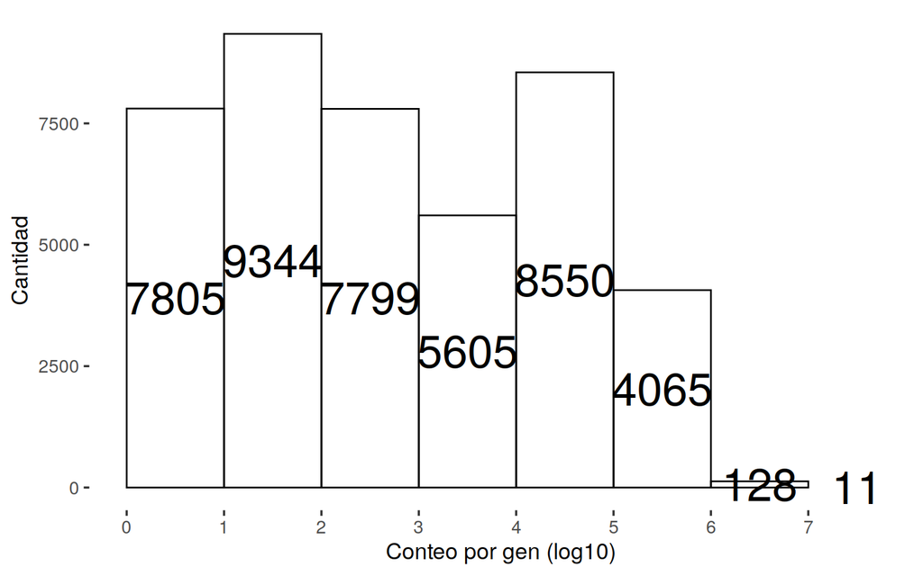

```r
gen_sum <- tibble(count = rowSums(counts(dds))) %>% tidylog::filter(count > 1)
ggplot(gen_sum, aes(x = log10(count))) +
  geom_histogram(color = 'black', alpha = 0, binwidth = 1, boundary = 0) +
  stat_bin(binwidth=1, boundary = 0, geom="text", colour="black", size=10,
           aes(label=..count.., y=..count../2)) +
  scale_x_continuous(breaks = 0:max(log10(gen_sum[['count']])),
                     limits = c(0, max(log10(gen_sum[['count']])))) +
  labs(x = 'Conteo por gen (log10)',
       y = 'Cantidad') +
  lmft
```

Figura 1: Histograma de conteos por histograma (log10)

Parece curioso que haya tantos genes con una expresión menor a 100, para 30 muestras totales parecen números muy bajos. Sería interesante considerar si deberíamos incluirlos o no. Por ahora no dispongo de un criterio mejor o sea que utilizaré el mismo criterio que en los apuntes.

# Análisis de expresión diferencial DSeq

En este caso disponemos de tres condiciones:

- NTI: *Non-Infiltrated Tissues*
- SFI: *Small Focal Infiltrates*
- ELI: *Extensive Lymphoid Infiltrates*

Vamos a aplicar varios enfoques en este caso:

En primer lugar compararemos las dos condiciones experimentales (SFI y ELI) contra la condición control (NTI) y luego compararemos las condiciones experimentales entre ellas.

Como análisis adicional vamos a comprobar si existe un efecto general de tratamiento comparando el modelo con el término *Group* y el modelo con el Intercept únicamente.

## Análisis por pares

Para el caso de las diferencias por pares utilizamos DESeq

```r
dds <- DESeq(dds, parallel = T, )
```

Extraemos los valores para cada contraste de interés y luego los plotearemos uno por uno

```r
rs_SFI_NIT <- results(dds, name='Group_SFI_vs_NIT')
rs_SFI_NIT <- results(dds, name='Group_ELI_vs_NIT')
rs_SFI_ELI <- results(dds, contrast=c('Group', 'SFI', 'ELI'))

#resultsNames(dds) # Obtain the names of the results comparisons
mcols(rs_SFI_ELI)
```

```
DataFrame with 6 rows and 2 columns
                       type                               description
                <character>                               <character>
baseMean       intermediate mean of normalized counts for all samples
log2FoldChange      results  log2 fold change (MLE): Group SFI vs ELI
lfcSE               results          standard error: Group SFI vs ELI
stat                results          Wald statistic: Group SFI vs ELI
pvalue              results       Wald test p-value: Group SFI vs ELI
padj                results                      BH adjusted p-values
```